# Midterm project

Muxi Ye

10/9/2020

## INTRODUCTION

In the past, many hospitals in California were damaged and evacuated due to earthquakes. Some even collapsed and led to death of patients. All told, the quake had placed a heavy burden on California’s hospital system. Therefore, the state officials demand that by 2030, the hospitals not only need to remain standing but can also continue to operate after the earthquakes. Our objective is to identify the best general acute care hospitals in California with reference to Structural Performance Category (SPC ratings range from 1 to 5 with SPC 1 assigned to buildings posing significant risk of collapse following a strong earthquake and SPC 5 assigned to buildings reasonably capable of providing services to the public following a strong earthquake) and Non-structural Performance Category (NPC ratings range from 1 to 5 with NPC 1 assigned to buildings where the safe and orderly evacuation following a strong earthquake cannot be assured and NPC 5 assigned to buildings capable of continued operation for 72 hours without any power, water and sewer services following a strong ground motion), and to look at the distribution and overall seismic safety performance of California hospitals in 2020.

## METHODS

The data were acquired online from California Health and Human Services Open Data Portal. We carefully checked all the variables in the original dataset. Easier variable names were created and used for county, SPC ratings and NPC ratings. For the variables of primary interest, implausible values and missing values, if any, were modified or removed as appropriate. For example, in the interpretation of the data dictionary, ‘N/A’ in SPC ratings indicates that the data are not applicable, therefore these values were excluded. After that, we only selected hospitals that are still in service for further analysis.

As each hospital may have different SPC and NPC ratings for different buildings, we used the mean score of all buildings in the hospital to compare and identify the one with the highest seismic safety performance. When comparing the hospitals among counties, we created a variable representing the overall seismic safety performance, which is equal to (SPC+NPC)/2, to look at the best 10 counties by table. Two bar charts were generated, showing the top 10 facilities with the most buildings and the top 10 counties with the most facilities respectively. Besides, a leaflet map was used to show the distribution of general acute care hospitals in California.

## PRELIMINARY RESULTS

In general, Amador, Kings, and Lassen are the three counties with the greatest overall seismic safety performance, with mean SPC and NPC ratings scoring 5 and 4 respectively. Colusa, Mariposa and Trinity, however, scores the lowest in CA, which only have 2 for SPC and 2 for NPC respectively. Of all California hospitals, Kaiser Foundation Hospital in San Diego was found to be the best acute care hospital regarding as the seismic ratings, which both achieved the highest scores in NPC and SPC.

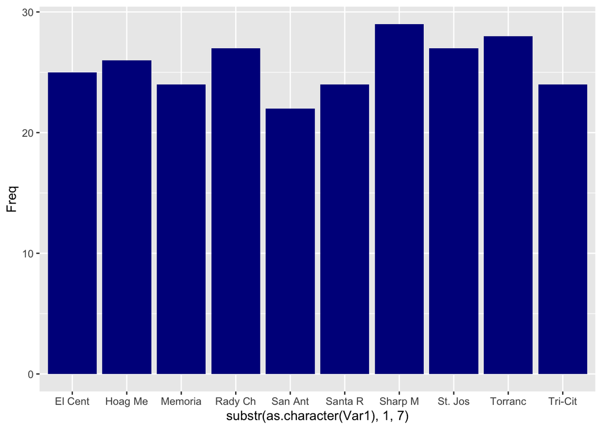

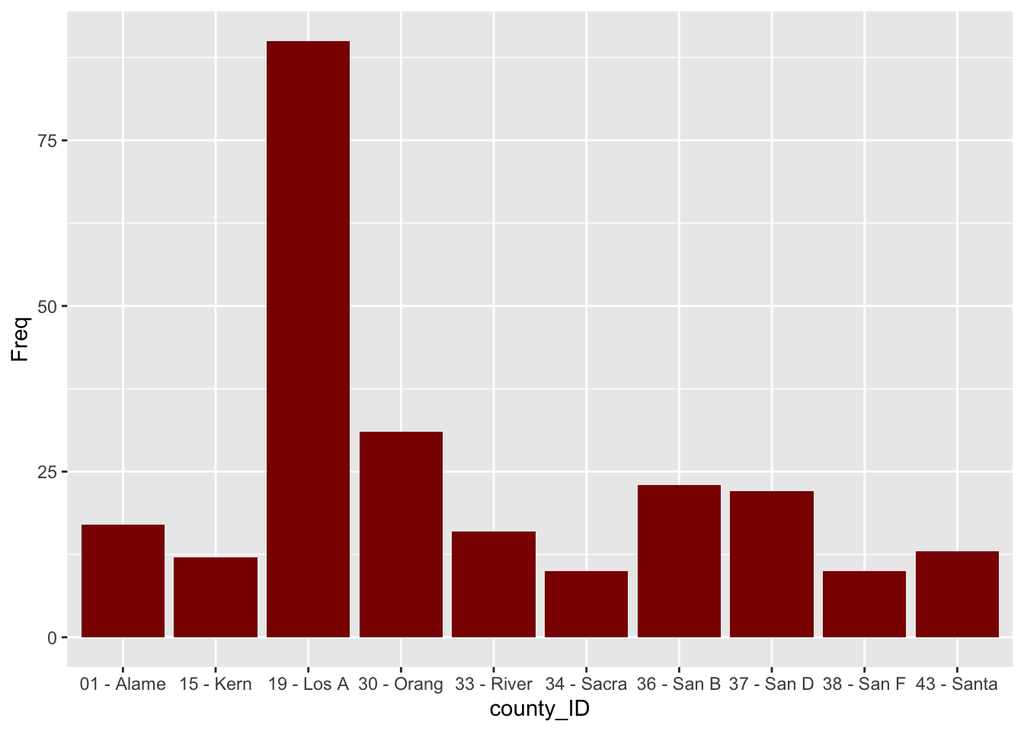

[interactive chart not shown]

Table1: Ordering Seismic Safety Performance For All Counties In CA

| county_name | Mean SPC | Mean NPC | perf |
| --- | --- | --- | --- |
| 03 - Amador | 5.000000 | 4.000000 | 4.500000 |
| 16 - Kings | 5.000000 | 4.000000 | 4.500000 |
| 18 - Lassen | 5.000000 | 4.000000 | 4.500000 |
| 08 - Del Norte | 4.500000 | 4.000000 | 4.250000 |
| 20 - Madera | 4.739130 | 3.565217 | 4.152174 |
| 26 - Mono | 4.750000 | 3.500000 | 4.125000 |
| 42 - Santa Barbara | 4.333333 | 3.424242 | 3.878788 |
| 47 - Siskiyou | 4.625000 | 3.000000 | 3.812500 |
| 24 - Merced | 4.142857 | 3.428571 | 3.785714 |
| 48 - Solano | 4.200000 | 3.200000 | 3.700000 |
| 31 - Placer | 4.500000 | 2.750000 | 3.625000 |
| 09 - El Dorado | 4.117647 | 2.941177 | 3.529412 |
| 29 - Nevada | 4.210526 | 2.842105 | 3.526316 |
| 49 - Sonoma | 3.943662 | 2.943662 | 3.443662 |
| 23 - Mendocino | 4.133333 | 2.733333 | 3.433333 |
| 14 - Inyo | 3.823529 | 2.705882 | 3.264706 |
| 13 - Imperial | 3.888889 | 2.611111 | 3.250000 |
| 55 - Tuolumne | 3.500000 | 3.000000 | 3.250000 |
| 27 - Monterey | 4.268293 | 2.219512 | 3.243902 |
| 34 - Sacramento | 3.893939 | 2.590909 | 3.242424 |
| 10 - Fresno | 3.688525 | 2.770492 | 3.229508 |
| 52 - Tehama | 4.142857 | 2.285714 | 3.214286 |
| 07 - Contra Costa | 3.872727 | 2.527273 | 3.200000 |
| 28 - Napa | 3.791667 | 2.583333 | 3.187500 |
| 36 - San Bernardino | 3.672727 | 2.654545 | 3.163636 |
| 15 - Kern | 3.752809 | 2.561798 | 3.157303 |
| 40 - San Luis Obispo | 3.806452 | 2.451613 | 3.129032 |
| 50 - Stanislaus | 3.974026 | 2.272727 | 3.123377 |
| 17 - Lake | 3.888889 | 2.222222 | 3.055556 |
| 43 - Santa Clara | 3.348624 | 2.761468 | 3.055046 |
| 44 - Santa Cruz | 3.600000 | 2.500000 | 3.050000 |
| 56 - Ventura | 3.367647 | 2.720588 | 3.044118 |
| 37 - San Diego | 3.462810 | 2.541322 | 3.002066 |
| 30 - Orange | 3.577093 | 2.418502 | 2.997797 |
| 12 - Humboldt | 3.441177 | 2.529412 | 2.985294 |
| 33 - Riverside | 3.537815 | 2.411765 | 2.974790 |
| 19 - Los Angeles | 3.343450 | 2.605431 | 2.974441 |
| 41 - San Mateo | 3.157895 | 2.789474 | 2.973684 |
| 54 - Tulare | 3.875000 | 1.937500 | 2.906250 |
| 39 - San Joaquin | 3.654762 | 2.142857 | 2.898810 |
| 32 - Plumas | 3.307692 | 2.461539 | 2.884615 |
| 04 - Butte | 3.658537 | 2.097561 | 2.878049 |
| 38 - San Francisco | 3.166667 | 2.533333 | 2.850000 |
| 57 - Yolo | 3.222222 | 2.444444 | 2.833333 |
| 35 - San Benito | 3.625000 | 2.000000 | 2.812500 |
| 01 - Alameda | 3.111111 | 2.288889 | 2.700000 |
| 45 - Shasta | 3.400000 | 2.000000 | 2.700000 |
| 05 - Calaveras | 3.333333 | 2.000000 | 2.666667 |
| 58 - Yuba | 2.888889 | 2.000000 | 2.444444 |
| 25 - Modoc | 2.857143 | 2.000000 | 2.428571 |
| 11 - Glenn | 2.363636 | 2.000000 | 2.181818 |
| 21 - Marin | 2.588235 | 1.647059 | 2.117647 |
| 06 - Colusa | 2.000000 | 2.000000 | 2.000000 |
| 22 - Mariposa | 2.000000 | 2.000000 | 2.000000 |
| 53 - Trinity | 2.000000 | 2.000000 | 2.000000 |

Note:  
perf=(Mean SPC+Mean NPC)/2

## CONCLUSION

The results show that Kaiser Foundation Hospital in San Diego is the best hospital in terms of seismic safety performance. We also found that most of the hospitals in California are located near Los Angeles, San Francisco and San Jose. Among all the counties in California, hospitals in Amador, Kings, and Lassen perform the best, while hospitals in Colusa, Mariposa and Trinity are the least reliable during the earthquake.